# The Ugly Plot Contest

#### The goal is to create a ggplot figure that breaks all the rules of sound figure design.

#### A good plot has the following:

- **Easily distinguishable colors (colorblind-friendly) or grayscale**
- **Properly labeled axes with appropriate scales**
- **Legible font size**
- **If a legend is present, it is easy to read and uses intuitive labels**
- **The correct geoms for the data types**
- **Doesn’t hide data distributions by simplifying into a single meaningless geom**
- **Facets that contain more than one data point, if there are facets at all**
- **Proper aesthetic scales … i.e., not a color gradient if a variable is discrete**

##### See [this very good site](https://rafalab.github.io/dsbook/data-visualization-principles.html) for a detailed look at what makes a good graph.

##### Making a truly bad graph can be automatic, but it takes a lot of skill to really tweak ggplot to get it to do what you want. That’s the point of this exercise; you will get practice at manipulating all aspects of how your plot is printed.

##### Here are some ugly plots from previous students:

[figure not shown]

Iris, like you’ve never seen it before. Wonderfully unacceptable colors and point sizes.

[figure not shown]

Nice, horrible work with custom point images and annotation.

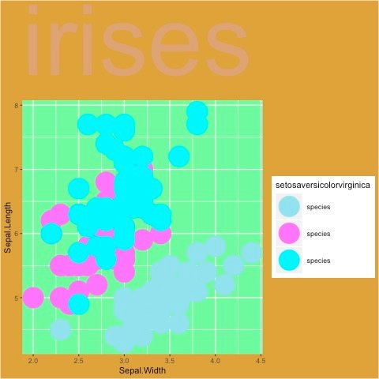

Horrible legend labels, low resolution, truly foul all around.

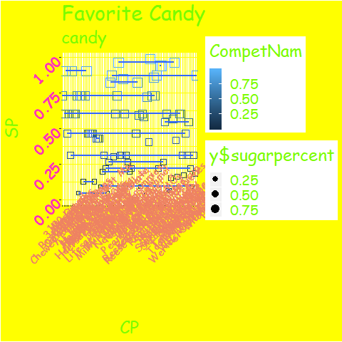

I have no idea. I just don’t understand.

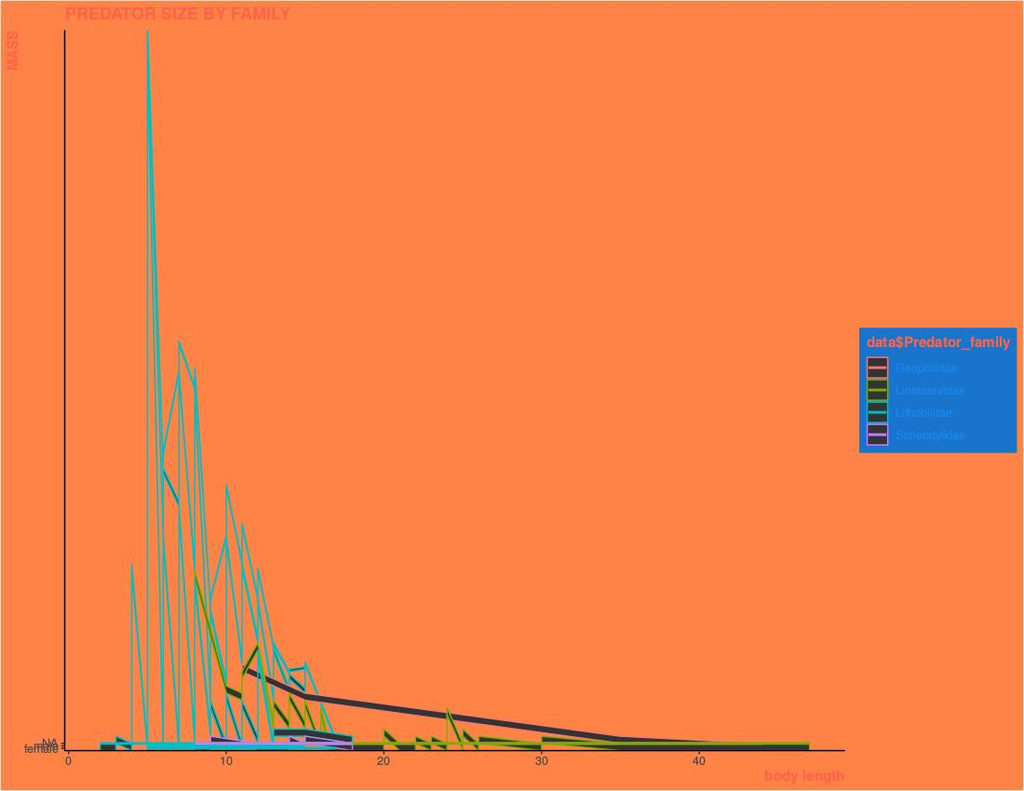

I think it’s kind of a line plot without grouping. I also think “mass” and “gender” somehow share the y-axis. I hate it.

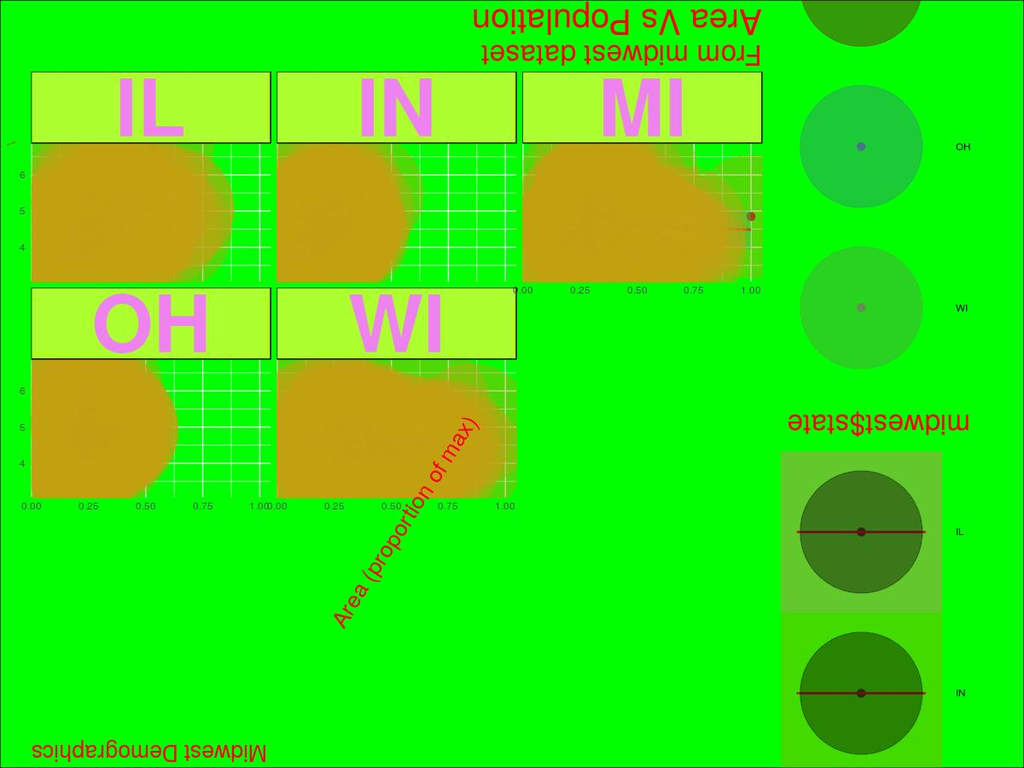

The double meaningless legends take this to a new level of greatness. Bonus points for low-res export.

## Think you can beat these?!